# Day six - 7/17

Marcus W. Beck, beck.marcus@epa.gov

### Meta-analysis

We absolutely need the mechanics and the connections, but we also need the big picture (meta-analysis) - they are complementary

Synthesis is the combination of two or more entitites - studies, regions, etc., the integration of evidence. Maps are useful - where the work has been done.

Zen - mind and body, zen synthesis - mind is synthesis, body is data.

Systematic review are similar to meta-analysis. A meta-analysis always has statistics, not always a p-value but gets effect sizes, variance, etc. The systematic review is one-step below meta-analysis.

The goal is to identify an effect size or average effort that matters to the big picture.

Synthesis is a counterweight to hyper-specialization - reduces silo effect among disciplines and sub-disciplines. Diversity promotes discovery, conceptualizes complexity, and copes with data deluge.

Synthesis will shift your view of statistical significance.

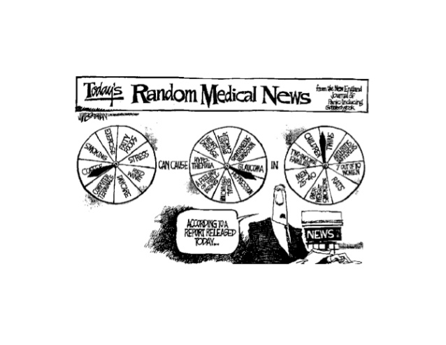

Effect sizes much more important than p-values, the strength of the difference - important for primary studies.

Synthesis framing - from low to hi - natural concepts -> functional concepts -> integrative concepts.

Steps of meta-analysis - questions, set of studies, predictions (summarize knowledge, meta-analysis). Each study is a sample point.

Systematic review has ‘pre-specified eligibility criteria’ aka your search terms for papers in the primary literature. This commonly uses a PRISMA report or approach, e.g., we started with 2000 papers, filtered down to 20. Can use Web of Science, SCOPUS, Google Scholar - use all. There are R packages to do this!!

Meta-analysis/systematic review also very important for gap analysis.

Meta-analysis always has an effect size, what was the strength of evidence plus variance and a measure of difference.

Effect size measured as:

- weighted difference of treatment - control
- natural log of treatment/control
- difference of treatement minus control divided by treatment plus control